# HappyDB

#### A Corpus of 100,000 Crowdsourced Happy Moments

## by Seif El-Eslam Hegazy

## - Preliminary Wrangling:

> [HappyDB](https://www.kaggle.com/ritresearch/happydb) is a corpus of more than 100,000 happy moments crowd-sourced via Amazon’s Mechanical Turk.

> Each worker is given the following task: What made you happy today? Reflect on the past 24 hours, and recall three actual events that happened to you that made you happy.

> Dataset has 2 csv files:
> - cleaned_hm.csv, the cleaned-up corpus of 100,000 crowd-sourced happy moments. The raw happy moments are retained for reference, and the author of each happy moment is represented by the his/her worker ID.
> - demographic.csv includes worker id, age, country, gender, marital status, and status of parenthood.

### What is the structure of your dataset?

> Dataset contains 100082 observations with 8 features.
- continuous quantitative data :
  - age
- nominal categorical data:
  - country
  - gender
  - martial
  - parenthood
  - category
  - reflection_period
- string list:
  - hm_words

### What is/are the main feature(s) of interest in your dataset?

> Figuring out what features affect people's happiness. What makes people happy.

### What features in the dataset do you think will help support your investigation into your feature(s) of interest?

> Actually all dataset features have an impact on happiness. Age, country, gender, martial and parenthood are considered main contributors of people happiness. Also category of happy moment indicates the common types of happiness. Reflection period indicates long/short term happy moments. How people described their happy moments also gives insight about happiness reasons.

## Univariate Exploration

### Age distribution:

```python
happy_df['age'].describe()
```

```
count    99878.000000
mean        32.421214
std          9.877295
min         17.000000
25%         26.000000
50%         30.000000
75%         36.000000
max         98.000000
Name: age, dtype: float64
```

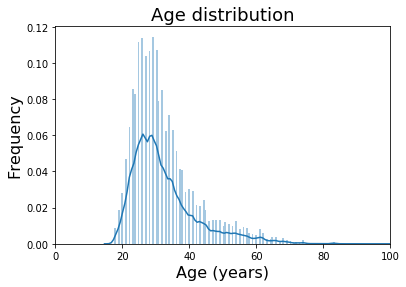

```python
sb.distplot(happy_df['age'], bins=150)
plt.xlim(0, 100)
plt.title('Age distribution', fontsize=18)
plt.xlabel('Age (years)', fontsize=16)
plt.ylabel('Frequency', fontsize=16);
```

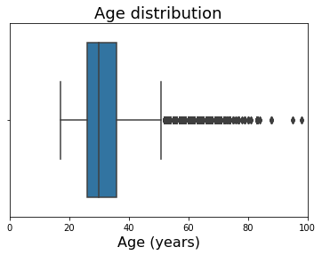

```python
sb.boxplot(happy_df['age']);
plt.xlim(0, 100)
plt.title('Age distribution', fontsize=18)
plt.xlabel('Age (years)', fontsize=16);
```

### Country exploration:

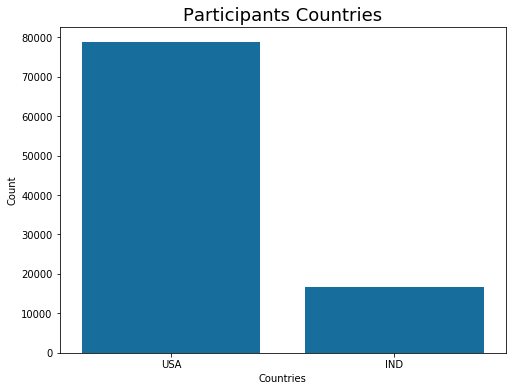

```python
plt.rcParams['figure.figsize'] = 8, 6
base_color = sb.color_palette('colorblind')[0]
sb.countplot(data=happy_df2, x='country', color=base_color);
# plt.xticks(rotation=90);
plt.title('Participants Countries', fontsize=18)
plt.xlabel('Countries');
plt.ylabel('Count');
```

### Gender exploration:

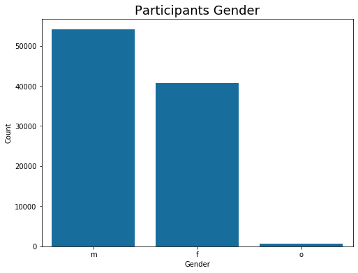

```python
plt.rcParams['figure.figsize'] = 8, 6
base_color = sb.color_palette('colorblind')[0]
sb.countplot(data=happy_df2, x='gender', color=base_color);
# plt.xticks(rotation=90);
plt.title('Participants Gender', fontsize=18)
plt.xlabel('Gender');
plt.ylabel('Count');
```

### Marital status exploration:

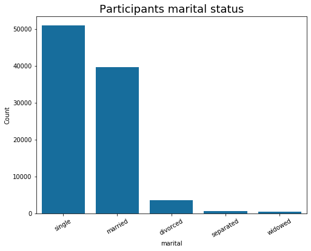

```python
plt.rcParams['figure.figsize'] = 8, 6
base_color = sb.color_palette('colorblind')[0]
sb.countplot(data=happy_df2, x='marital', color=base_color, order = happy_df2['marital'].value_counts().index);
plt.xticks(rotation=30);
plt.title('Participants marital status', fontsize=18)
plt.xlabel('marital');
plt.ylabel('Count');
```

> Major participants are single, then married people. Minor participants are divorced, separated and widowed.

### Parenthood exploration:

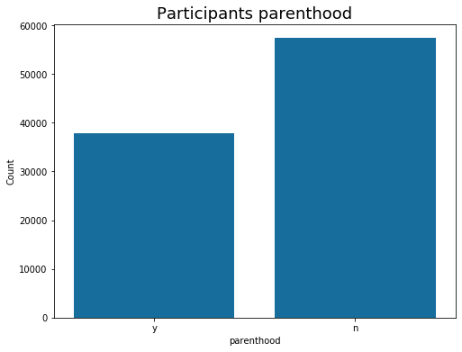

```python
plt.rcParams['figure.figsize'] = 8, 6
base_color = sb.color_palette('colorblind')[0]
sb.countplot(data=happy_df2, x='parenthood', color=base_color);
# plt.xticks(rotation=90);
plt.title('Participants parenthood', fontsize=18)
plt.xlabel('parenthood');
plt.ylabel('Count');
```

### Reflection period exploration:

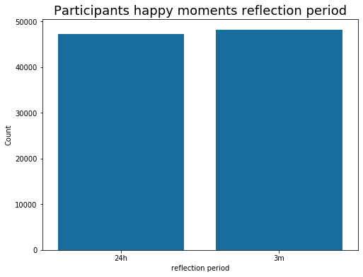

```python
plt.rcParams['figure.figsize'] = 8, 6
base_color = sb.color_palette('colorblind')[0]
sb.countplot(data=happy_df2, x='reflection_period', color=base_color);
# plt.xticks(rotation=90);
plt.title('Participants happy moments reflection period', fontsize=18)
plt.xlabel('reflection period');
plt.ylabel('Count');
```

### Happiness category exploration:

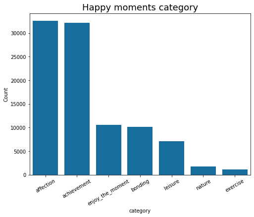

```python
plt.rcParams['figure.figsize'] = 8, 6
base_color = sb.color_palette('colorblind')[0]
sb.countplot(data=happy_df2, x='category', color=base_color, order = happy_df2['category'].value_counts().index);
plt.xticks(rotation=30);
plt.title('Happy moments category', fontsize=18)
plt.xlabel('category');
plt.ylabel('Count');
```

### How people described their happy moments:

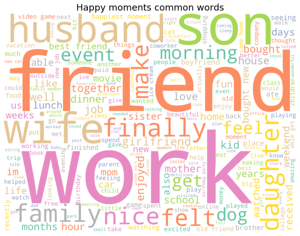

```python
ignore_words = ['happy', 'day', 'got', 'went', 'today', 'made', 'one', 'two', 'time', 'last',
                'first', 'going', 'getting', 'took', 'found', 'lot', 'really', 'saw', 'see',
                'month', 'week', 'day', 'yesterday', 'year', 'ago', 'now', 'still', 'since',
                'something', 'great', 'good', 'long', 'thing', 'toi', 'without', 'yesteri',
                '2s', 'toand', 'ing', 'night', 'never', 'started']
wordcloud = WordCloud(background_color="white", stopwords=set(ignore_words), height=2700, width=3600).generate(common_words_str)
plt.figure( figsize=(14,8) )
plt.title('Happy moments common words', fontsize=18)
plt.imshow(wordcloud.recolor(colormap=plt.get_cmap('Set2')), interpolation='bilinear')
plt.axis("off");
```

> Most of happy moments related to: **"work", "friendship", "family", "meals", "emotions", "pets", "gathering", "buying", "achievements"**

## Bivariate Exploration

### Common types of happy moments VS age:

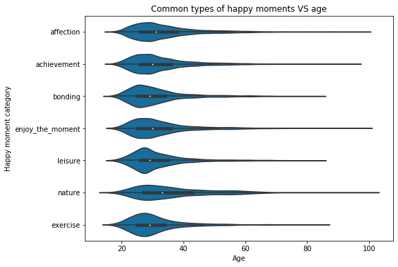

```python
sb.violinplot(data=happy_df2, x='age', y='category', color=base_color);
# plt.xticks(rotation=30);
plt.title('Common types of happy moments VS age');
plt.xlabel('Age');
plt.ylabel('Happy moment category');
```

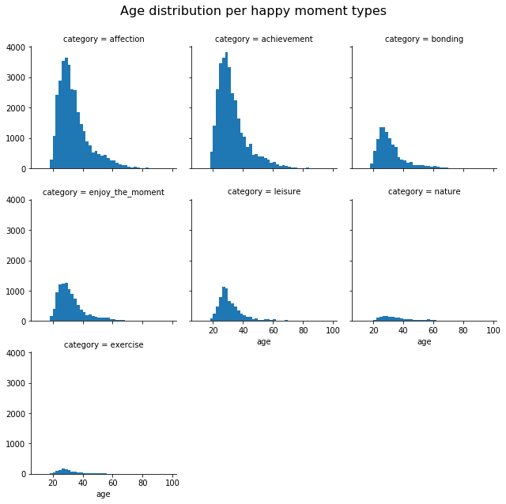

```python
bin_edges = np.arange(10, happy_df2['age'].max()+1, 2)
g = sb.FacetGrid(data = happy_df2, col = 'category',col_wrap = 3, size = 3, margin_titles=True)
g.map(plt.hist, "age", bins = bin_edges);
plt.subplots_adjust(top=0.9);
# plt.subplots_adjust(hspace=0.5, wspace=0.4)
g.fig.suptitle('Age distribution per happy moment types', fontsize=16);
```

> - Age distributions of affection & achievement happy moments are narrow and big.
> - Lowest age distributions are for nature & exercise moments.
> - So main happy moments are affection & achievement.

### Common types of happy moments VS gender:

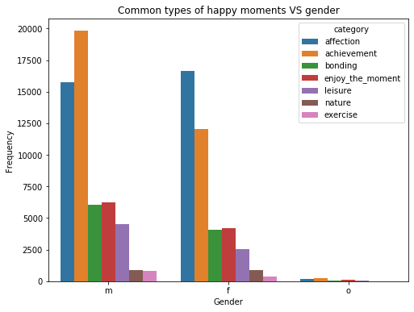

```python
sb.countplot(data = happy_df2, x = 'gender', hue = 'category')
# plt.xticks(rotation=30);
plt.title('Common types of happy moments VS gender');
plt.xlabel('Gender');
plt.ylabel('Frequency');
```

> - Males have more achievement happy moments than females significantly.
> - Females have higher affection happy moments than males.

### Common types of happy moments VS marital status:

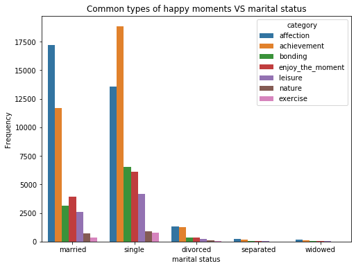

```python
sb.countplot(data = happy_df2, x = 'marital', hue = 'category')
# plt.xticks(rotation=30);
plt.title('Common types of happy moments VS marital status');
plt.xlabel('marital status');
plt.ylabel('Frequency');
```

> - Married people have affection happy moments than achievement ones significantly.
> - Single people have achievement happy moments than affection ones significantly.
> - Single people have bonding, enjoy_the_moment and leisure moments than married people.

### Common types of happy moments VS parenthood:

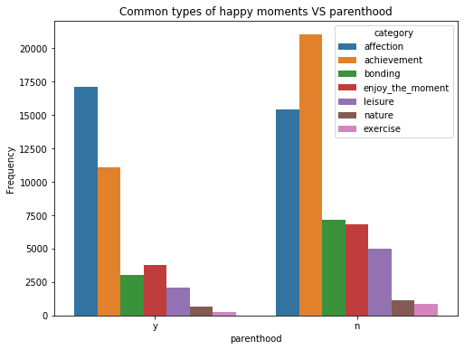

```python
sb.countplot(data = happy_df2, x = 'parenthood', hue = 'category')
# plt.xticks(rotation=30);
plt.title('Common types of happy moments VS parenthood');
plt.xlabel('parenthood');
plt.ylabel('Frequency');
```

> - People with parenthood have more affection happy moments than people with no parenthood.
> - People with no parenthood have more achievement happy moments than people with parenthood significantly.
> - People with no parenthood have more bonding, enjoy_the_moment and leisure than than people with parenthood.

### Reflection period of happy moments types:

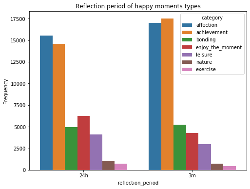

```python
sb.countplot(data = happy_df2, x = 'reflection_period', hue = 'category')
# plt.xticks(rotation=30);
plt.title('Reflection period of happy moments types');
plt.xlabel('reflection_period');
plt.ylabel('Frequency');
```

> This graph needs another factor such as marital or parenthood to know on which base happy moments have higher reflection period

### Common types of happy moments VS country:

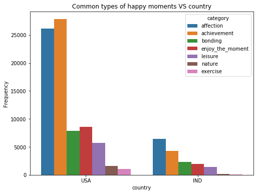

```python
sb.countplot(data = happy_df2, x = 'country', hue = 'category')
# plt.xticks(rotation=30);
plt.title('Common types of happy moments VS country');
plt.xlabel('country');
plt.ylabel('Frequency');
```

> - However USA observations are higher than Indian ones, the pattern of India happy moments differ than USA ones.
> - USA people have affection & achievement happy moments than other types significantly than India people.

### What people says:

#### - Males Vs Females:

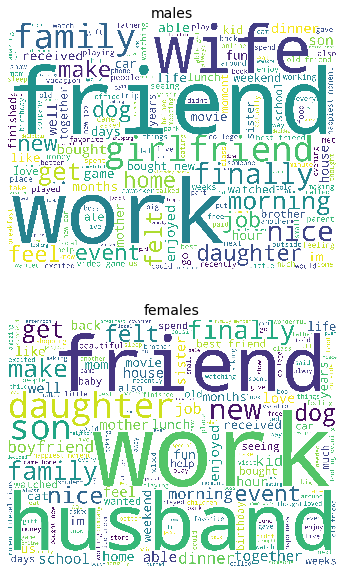

```python
fig = plt.figure(figsize=(10,10))
for i, v in enumerate([('m', 'males'), ('f', 'females')]):
    common_words = get_common_words('gender', v[0])
    ax = fig.add_subplot(2,1,i+1)
    ax.set_title(v[1], fontsize=14)
    wordcloud = WordCloud(background_color="white", stopwords=set(ignore_words), height=2700, width=3600).generate(common_words)

    ax.imshow(wordcloud)
    ax.axis('off')
```

> There is no much difference in moments words for males and females.

#### - Single Vs Married:

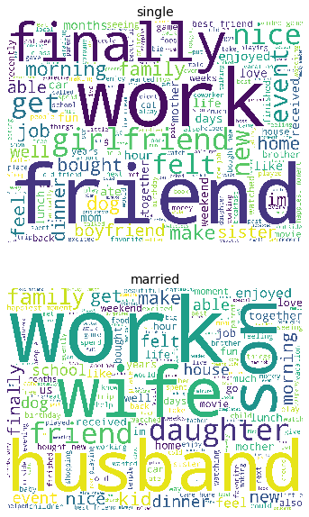

```python
fig = plt.figure(figsize=(10,10))
for i, v in enumerate([('single', 'single'), ('married', 'married')]):
    common_words = get_common_words('marital', v[0])
    ax = fig.add_subplot(2,1,i+1)
    ax.set_title(v[1], fontsize=14)
    wordcloud = WordCloud(background_color="white", stopwords=set(ignore_words), height=2700, width=3600).generate(common_words)

    ax.imshow(wordcloud)
    ax.axis('off')
```

> - single people said more: "work", "friend", "finally", "bought"
> - Married people said more: "work", "husband", "wife", "son", "daughter"

#### - USA Vs India:

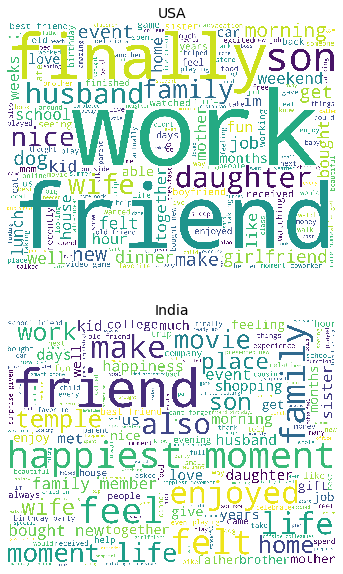

```python
fig = plt.figure(figsize=(10,10))
for i, v in enumerate([('USA', 'USA'), ('IND', 'India')]):
    common_words = get_common_words('country', v[0])
    ax = fig.add_subplot(2,1,i+1)
    ax.set_title(v[1], fontsize=14)
    wordcloud = WordCloud(background_color="white", stopwords=set(ignore_words), height=2700, width=3600).generate(common_words)

    ax.imshow(wordcloud)
    ax.axis('off')
```

> - There is a significant difference in moments words of people of USA vs India.
> - USA people happy moments about: "Work", "friend", "finally", "family"
> - Achievement words in Indian people moments are less common. They fouced on affection moments words like: "friend", "happiest", "moment", "feel", "family"

### Gender Vs Country:

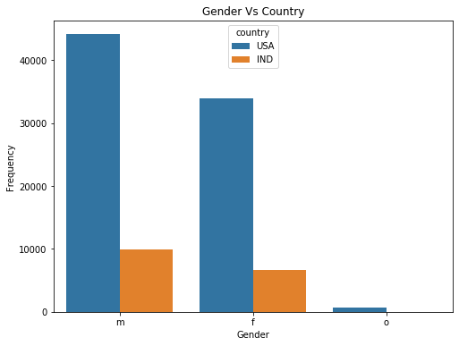

```python
sb.countplot(data = happy_df2, x = 'gender', hue = 'country')
# plt.xticks(rotation=30);
plt.title('Gender Vs Country');
plt.xlabel('Gender');
plt.ylabel('Frequency');
```

### Marital status Vs Country:

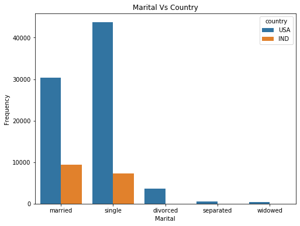

```python
sb.countplot(data = happy_df2, x = 'marital', hue = 'country')
# plt.xticks(rotation=30);
plt.title('Marital Vs Country');
plt.xlabel('Marital');
plt.ylabel('Frequency');
```

### Parenthood Vs Country:

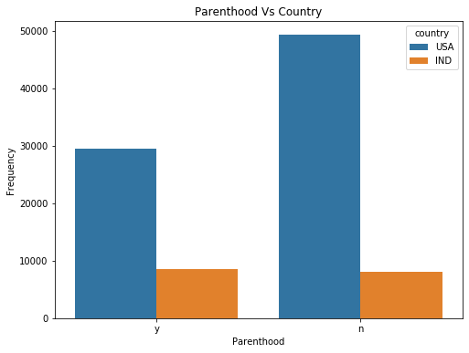

```python
sb.countplot(data = happy_df2, x = 'parenthood', hue = 'country')
# plt.xticks(rotation=30);
plt.title('Parenthood Vs Country');
plt.xlabel('Parenthood');
plt.ylabel('Frequency');
```

> - Across all Indian observations, married people are greater than single ones. About 50% of Indian observations have parenthood.
> - Across All USA observations, single people are greater than married ones. About 60% of USA observations don't have parethood.

### Talk about some of the relationships you observed in this part of the investigation. How did the feature(s) of interest vary with other features in the dataset?

> Types of happy moments vary with:

> ```
> - Gender: As males have more achievement happy moments than females.
> - Marital: As single people have more achievement happy moments than married ones.
> - Country: Indian people have more affection happy moments, and less than achievement comparing to American people.
> ```

### Did you observe any interesting relationships between the other features (not the main feature(s) of interest)?

> Country Vs marital has an interesting relationship. Across all Indian observations, married people are greater than single ones. About 50% of Indian observations have parenthood. Across All USA observations, single people are greater than married ones. About 60% of USA observations don't have parethood.